# Risk Factor Analysis

## Outcome Variable

**Outcome Variable:** stunted

## Predictor Variables

**Intervention Variable:** perdiar6

**Adjustment Set:**

- arm
- sex
- W_mage
- meducyrs
- W_mhtcm
- W_mwtkg
- W_mbmi
- W_birthwt
- W_birthlen
- W_nrooms
- month
- brthmon
- impfloor
- impsan
- safeh20
- delta_W_mage
- delta_meducyrs
- delta_W_mhtcm
- delta_W_mwtkg
- delta_W_mbmi
- delta_W_birthwt
- delta_W_birthlen
- delta_W_nrooms
- delta_month
- delta_brthmon
- delta_impfloor
- delta_impsan
- delta_safeh20

## Stratifying Variables

The analysis was stratified on these variable(s):

- agecat
- studyid
- country

## Data Summary

| agecat | studyid | country | perdiar6 | stunted | n_cell | n |
| --- | --- | --- | --- | --- | --- | --- |
| Birth | ki0047075b-MAL-ED | BANGLADESH | 0% | 0 | 71 | 257 |
| Birth | ki0047075b-MAL-ED | BANGLADESH | 0% | 1 | 15 | 257 |
| Birth | ki0047075b-MAL-ED | BANGLADESH | (0%, 5%] | 0 | 83 | 257 |
| Birth | ki0047075b-MAL-ED | BANGLADESH | (0%, 5%] | 1 | 13 | 257 |
| Birth | ki0047075b-MAL-ED | BANGLADESH | >5% | 0 | 56 | 257 |
| Birth | ki0047075b-MAL-ED | BANGLADESH | >5% | 1 | 19 | 257 |
| Birth | ki0047075b-MAL-ED | BRAZIL | 0% | 0 | 156 | 191 |
| Birth | ki0047075b-MAL-ED | BRAZIL | 0% | 1 | 20 | 191 |
| Birth | ki0047075b-MAL-ED | BRAZIL | (0%, 5%] | 0 | 12 | 191 |
| Birth | ki0047075b-MAL-ED | BRAZIL | (0%, 5%] | 1 | 1 | 191 |
| Birth | ki0047075b-MAL-ED | BRAZIL | >5% | 0 | 2 | 191 |
| Birth | ki0047075b-MAL-ED | BRAZIL | >5% | 1 | 0 | 191 |
| Birth | ki0047075b-MAL-ED | INDIA | 0% | 0 | 37 | 206 |
| Birth | ki0047075b-MAL-ED | INDIA | 0% | 1 | 10 | 206 |
| Birth | ki0047075b-MAL-ED | INDIA | (0%, 5%] | 0 | 90 | 206 |
| Birth | ki0047075b-MAL-ED | INDIA | (0%, 5%] | 1 | 19 | 206 |
| Birth | ki0047075b-MAL-ED | INDIA | >5% | 0 | 46 | 206 |
| Birth | ki0047075b-MAL-ED | INDIA | >5% | 1 | 4 | 206 |
| Birth | ki0047075b-MAL-ED | NEPAL | 0% | 0 | 55 | 173 |
| Birth | ki0047075b-MAL-ED | NEPAL | 0% | 1 | 5 | 173 |
| Birth | ki0047075b-MAL-ED | NEPAL | (0%, 5%] | 0 | 53 | 173 |
| Birth | ki0047075b-MAL-ED | NEPAL | (0%, 5%] | 1 | 4 | 173 |
| Birth | ki0047075b-MAL-ED | NEPAL | >5% | 0 | 47 | 173 |
| Birth | ki0047075b-MAL-ED | NEPAL | >5% | 1 | 9 | 173 |
| Birth | ki0047075b-MAL-ED | PERU | 0% | 0 | 71 | 287 |
| Birth | ki0047075b-MAL-ED | PERU | 0% | 1 | 12 | 287 |
| Birth | ki0047075b-MAL-ED | PERU | (0%, 5%] | 0 | 76 | 287 |
| Birth | ki0047075b-MAL-ED | PERU | (0%, 5%] | 1 | 12 | 287 |
| Birth | ki0047075b-MAL-ED | PERU | >5% | 0 | 106 | 287 |
| Birth | ki0047075b-MAL-ED | PERU | >5% | 1 | 10 | 287 |

[output cut: 234 more lines]

The following strata were considered:

- agecat: 24 months, studyid: ki0047075b-MAL-ED, country: BANGLADESH
- agecat: 24 months, studyid: ki0047075b-MAL-ED, country: BRAZIL
- agecat: 24 months, studyid: ki0047075b-MAL-ED, country: INDIA
- agecat: 24 months, studyid: ki0047075b-MAL-ED, country: NEPAL
- agecat: 24 months, studyid: ki0047075b-MAL-ED, country: PERU
- agecat: 24 months, studyid: ki0047075b-MAL-ED, country: SOUTH AFRICA
- agecat: 24 months, studyid: ki0047075b-MAL-ED, country: TANZANIA, UNITED REPUBLIC OF
- agecat: 24 months, studyid: ki1017093-NIH-Birth, country: BANGLADESH
- agecat: 24 months, studyid: ki1017093b-PROVIDE, country: BANGLADESH
- agecat: 24 months, studyid: ki1017093c-NIH-Crypto, country: BANGLADESH
- agecat: 24 months, studyid: ki1114097-CMIN, country: BANGLADESH
- agecat: 24 months, studyid: ki1114097-CMIN, country: GUINEA-BISSAU
- agecat: 24 months, studyid: ki1114097-CMIN, country: PERU
- agecat: 24 months, studyid: ki1114097-CONTENT, country: PERU
- agecat: 6 months, studyid: ki0047075b-MAL-ED, country: BANGLADESH
- agecat: 6 months, studyid: ki0047075b-MAL-ED, country: BRAZIL
- agecat: 6 months, studyid: ki0047075b-MAL-ED, country: INDIA
- agecat: 6 months, studyid: ki0047075b-MAL-ED, country: NEPAL
- agecat: 6 months, studyid: ki0047075b-MAL-ED, country: PERU
- agecat: 6 months, studyid: ki0047075b-MAL-ED, country: SOUTH AFRICA
- agecat: 6 months, studyid: ki0047075b-MAL-ED, country: TANZANIA, UNITED REPUBLIC OF
- agecat: 6 months, studyid: ki1000109-ResPak, country: PAKISTAN
- agecat: 6 months, studyid: ki1017093-NIH-Birth, country: BANGLADESH
- agecat: 6 months, studyid: ki1017093b-PROVIDE, country: BANGLADESH
- agecat: 6 months, studyid: ki1017093c-NIH-Crypto, country: BANGLADESH
- agecat: 6 months, studyid: ki1114097-CMIN, country: BANGLADESH
- agecat: 6 months, studyid: ki1114097-CMIN, country: BRAZIL
- agecat: 6 months, studyid: ki1114097-CMIN, country: GUINEA-BISSAU
- agecat: 6 months, studyid: ki1114097-CMIN, country: PERU
- agecat: 6 months, studyid: ki1114097-CONTENT, country: PERU
- agecat: Birth, studyid: ki0047075b-MAL-ED, country: BANGLADESH
- agecat: Birth, studyid: ki0047075b-MAL-ED, country: BRAZIL
- agecat: Birth, studyid: ki0047075b-MAL-ED, country: INDIA
- agecat: Birth, studyid: ki0047075b-MAL-ED, country: NEPAL
- agecat: Birth, studyid: ki0047075b-MAL-ED, country: PERU
- agecat: Birth, studyid: ki0047075b-MAL-ED, country: SOUTH AFRICA
- agecat: Birth, studyid: ki0047075b-MAL-ED, country: TANZANIA, UNITED REPUBLIC OF
- agecat: Birth, studyid: ki1000109-ResPak, country: PAKISTAN
- agecat: Birth, studyid: ki1017093-NIH-Birth, country: BANGLADESH
- agecat: Birth, studyid: ki1017093c-NIH-Crypto, country: BANGLADESH
- agecat: Birth, studyid: ki1114097-CMIN, country: BANGLADESH
- agecat: Birth, studyid: ki1114097-CMIN, country: BRAZIL
- agecat: Birth, studyid: ki1114097-CMIN, country: PERU
- agecat: Birth, studyid: ki1114097-CONTENT, country: PERU

### Dropped Strata

Some strata were dropped due to rare outcomes:

- agecat: Birth, studyid: ki0047075b-MAL-ED, country: BRAZIL
- agecat: Birth, studyid: ki0047075b-MAL-ED, country: INDIA
- agecat: Birth, studyid: ki0047075b-MAL-ED, country: NEPAL
- agecat: Birth, studyid: ki0047075b-MAL-ED, country: SOUTH AFRICA
- agecat: Birth, studyid: ki0047075b-MAL-ED, country: TANZANIA, UNITED REPUBLIC OF
- agecat: Birth, studyid: ki1000109-ResPak, country: PAKISTAN
- agecat: Birth, studyid: ki1017093-NIH-Birth, country: BANGLADESH
- agecat: Birth, studyid: ki1017093c-NIH-Crypto, country: BANGLADESH
- agecat: Birth, studyid: ki1114097-CMIN, country: BANGLADESH
- agecat: Birth, studyid: ki1114097-CMIN, country: BRAZIL
- agecat: Birth, studyid: ki1114097-CMIN, country: PERU
- agecat: Birth, studyid: ki1114097-CONTENT, country: PERU
- agecat: 6 months, studyid: ki0047075b-MAL-ED, country: BRAZIL
- agecat: 6 months, studyid: ki0047075b-MAL-ED, country: NEPAL
- agecat: 6 months, studyid: ki0047075b-MAL-ED, country: SOUTH AFRICA
- agecat: 6 months, studyid: ki1114097-CMIN, country: BRAZIL
- agecat: 6 months, studyid: ki1114097-CONTENT, country: PERU
- agecat: 24 months, studyid: ki0047075b-MAL-ED, country: BRAZIL
- agecat: 24 months, studyid: ki0047075b-MAL-ED, country: SOUTH AFRICA
- agecat: 24 months, studyid: ki1114097-CONTENT, country: PERU

## Methods Detail

We’re interested in the causal parameters $E[Y_a]$ for all values of $a \in \mathcal{A}$. These parameters represent the mean outcome if, possibly contrary to fact, we intervened to set all units to have $A=a$. Under the randomization and positivity assumptions, these are identified by the statistical parameters $\psi_a=E_W[E_{Y|A,W}(Y|A=a,W)]$. In addition, we’re interested in the mean of $Y$, $E[Y]$ under no intervention (the observed mean). We will estimate these parameters by using SuperLearner to fit the relevant likelihood factors – $E_{Y|A,W}(Y|A=a,W)$ and $p(A=a|W)$, and then updating our likelihood fit using a joint TMLE.

For unadjusted analyses ($W=\{\}$), initial likelihoods were estimated using Lrnr_glm to estimate the simple $E(Y|A)$ and Lrnr_mean to estimate $p(A)$. For adjusted analyses, a small library containing Lrnr_glmnet, Lrnr_xgboost, and Lrnr_mean was used.

Having estimated these parameters, we will then use the delta method to estimate relative risks and attributable risks relative to a prespecified baseline level of $A$.

# Results Detail

## Results Plots

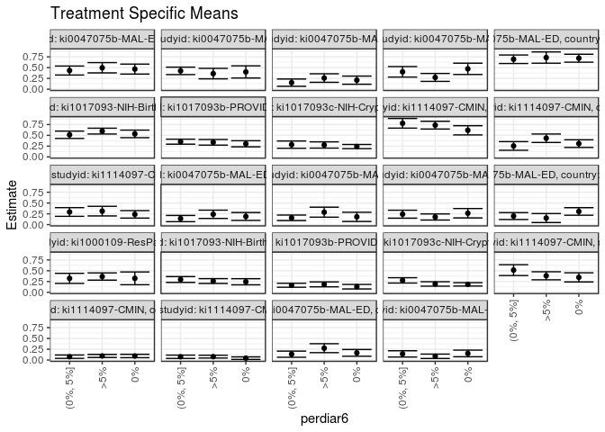

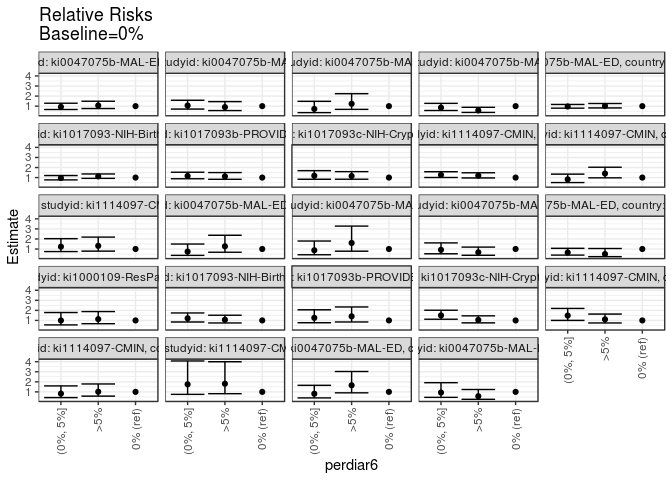

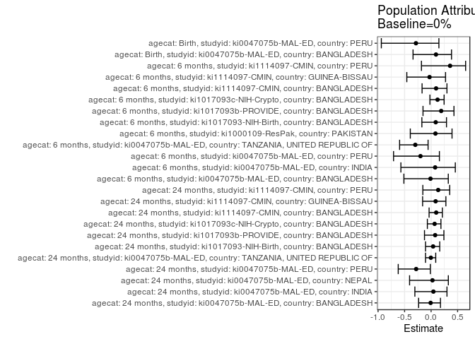

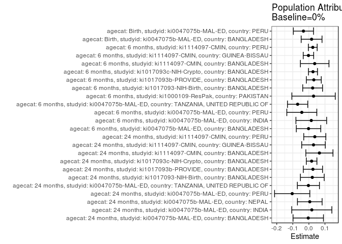

## Results Table

### Parameter: TSM

| agecat | studyid | country | intervention_level | baseline_level | estimate | ci_lower | ci_upper |
| --- | --- | --- | --- | --- | --- | --- | --- |
| Birth | ki0047075b-MAL-ED | BANGLADESH | 0% | NA | 0.1660216 | 0.0880461 | 0.2439970 |
| Birth | ki0047075b-MAL-ED | BANGLADESH | (0%, 5%] | NA | 0.1350965 | 0.0637775 | 0.2064155 |
| Birth | ki0047075b-MAL-ED | BANGLADESH | >5% | NA | 0.2746937 | 0.1709145 | 0.3784730 |
| Birth | ki0047075b-MAL-ED | PERU | 0% | NA | 0.1523425 | 0.0756086 | 0.2290764 |
| Birth | ki0047075b-MAL-ED | PERU | (0%, 5%] | NA | 0.1420425 | 0.0693122 | 0.2147728 |
| Birth | ki0047075b-MAL-ED | PERU | >5% | NA | 0.0867996 | 0.0359316 | 0.1376677 |
| 6 months | ki0047075b-MAL-ED | BANGLADESH | 0% | NA | 0.1888218 | 0.0972520 | 0.2803916 |
| 6 months | ki0047075b-MAL-ED | BANGLADESH | (0%, 5%] | NA | 0.1400716 | 0.0680664 | 0.2120769 |
| 6 months | ki0047075b-MAL-ED | BANGLADESH | >5% | NA | 0.2396184 | 0.1436640 | 0.3355727 |
| 6 months | ki0047075b-MAL-ED | INDIA | 0% | NA | 0.1800000 | 0.0732843 | 0.2867157 |
| 6 months | ki0047075b-MAL-ED | INDIA | (0%, 5%] | NA | 0.1574803 | 0.0939953 | 0.2209654 |
| 6 months | ki0047075b-MAL-ED | INDIA | >5% | NA | 0.2881356 | 0.1723269 | 0.4039443 |
| 6 months | ki0047075b-MAL-ED | PERU | 0% | NA | 0.2637854 | 0.1552641 | 0.3723067 |
| 6 months | ki0047075b-MAL-ED | PERU | (0%, 5%] | NA | 0.2419779 | 0.1497753 | 0.3341804 |
| 6 months | ki0047075b-MAL-ED | PERU | >5% | NA | 0.1769452 | 0.1061171 | 0.2477734 |
| 6 months | ki0047075b-MAL-ED | TANZANIA, UNITED REPUBLIC OF | 0% | NA | 0.3047619 | 0.2165390 | 0.3929848 |
| 6 months | ki0047075b-MAL-ED | TANZANIA, UNITED REPUBLIC OF | (0%, 5%] | NA | 0.1979167 | 0.1180539 | 0.2777794 |
| 6 months | ki0047075b-MAL-ED | TANZANIA, UNITED REPUBLIC OF | >5% | NA | 0.1521739 | 0.0481643 | 0.2561836 |
| 6 months | ki1000109-ResPak | PAKISTAN | 0% | NA | 0.3241606 | 0.1761533 | 0.4721678 |
| 6 months | ki1000109-ResPak | PAKISTAN | (0%, 5%] | NA | 0.3233518 | 0.2061296 | 0.4405739 |
| 6 months | ki1000109-ResPak | PAKISTAN | >5% | NA | 0.3659570 | 0.2822976 | 0.4496164 |
| 6 months | ki1017093-NIH-Birth | BANGLADESH | 0% | NA | 0.2447741 | 0.1739904 | 0.3155579 |
| 6 months | ki1017093-NIH-Birth | BANGLADESH | (0%, 5%] | NA | 0.2969804 | 0.2294777 | 0.3644832 |
| 6 months | ki1017093-NIH-Birth | BANGLADESH | >5% | NA | 0.2614572 | 0.2058981 | 0.3170164 |
| 6 months | ki1017093b-PROVIDE | BANGLADESH | 0% | NA | 0.1305289 | 0.0779437 | 0.1831141 |
| 6 months | ki1017093b-PROVIDE | BANGLADESH | (0%, 5%] | NA | 0.1644279 | 0.1177430 | 0.2111128 |
| 6 months | ki1017093b-PROVIDE | BANGLADESH | >5% | NA | 0.1840271 | 0.1272002 | 0.2408539 |
| 6 months | ki1017093c-NIH-Crypto | BANGLADESH | 0% | NA | 0.1842561 | 0.1451676 | 0.2233445 |
| 6 months | ki1017093c-NIH-Crypto | BANGLADESH | (0%, 5%] | NA | 0.2767253 | 0.2150934 | 0.3383571 |
| 6 months | ki1017093c-NIH-Crypto | BANGLADESH | >5% | NA | 0.1938069 | 0.1423242 | 0.2452896 |
| 6 months | ki1114097-CMIN | BANGLADESH | 0% | NA | 0.3466312 | 0.2407595 | 0.4525028 |
| 6 months | ki1114097-CMIN | BANGLADESH | (0%, 5%] | NA | 0.5147623 | 0.3890759 | 0.6404486 |
| 6 months | ki1114097-CMIN | BANGLADESH | >5% | NA | 0.3835324 | 0.2903297 | 0.4767350 |
| 6 months | ki1114097-CMIN | GUINEA-BISSAU | 0% | NA | 0.0934598 | 0.0538532 | 0.1330664 |
| 6 months | ki1114097-CMIN | GUINEA-BISSAU | (0%, 5%] | NA | 0.0773473 | 0.0386344 | 0.1160602 |
| 6 months | ki1114097-CMIN | GUINEA-BISSAU | >5% | NA | 0.0947498 | 0.0592394 | 0.1302601 |
| 6 months | ki1114097-CMIN | PERU | 0% | NA | 0.0434783 | 0.0139889 | 0.0729676 |
| 6 months | ki1114097-CMIN | PERU | (0%, 5%] | NA | 0.0760870 | 0.0377470 | 0.1144270 |
| 6 months | ki1114097-CMIN | PERU | >5% | NA | 0.0786517 | 0.0463369 | 0.1109664 |
| 24 months | ki0047075b-MAL-ED | BANGLADESH | 0% | NA | 0.4662144 | 0.3508904 | 0.5815384 |
| 24 months | ki0047075b-MAL-ED | BANGLADESH | (0%, 5%] | NA | 0.4325039 | 0.3286228 | 0.5363851 |
| 24 months | ki0047075b-MAL-ED | BANGLADESH | >5% | NA | 0.4968315 | 0.3777418 | 0.6159213 |
| 24 months | ki0047075b-MAL-ED | INDIA | 0% | NA | 0.4003310 | 0.2596429 | 0.5410191 |
| 24 months | ki0047075b-MAL-ED | INDIA | (0%, 5%] | NA | 0.4244452 | 0.3376674 | 0.5112230 |
| 24 months | ki0047075b-MAL-ED | INDIA | >5% | NA | 0.3610396 | 0.2397707 | 0.4823084 |
| 24 months | ki0047075b-MAL-ED | NEPAL | 0% | NA | 0.2093436 | 0.1149493 | 0.3037378 |
| 24 months | ki0047075b-MAL-ED | NEPAL | (0%, 5%] | NA | 0.1517832 | 0.0676035 | 0.2359629 |
| 24 months | ki0047075b-MAL-ED | NEPAL | >5% | NA | 0.2585659 | 0.1593720 | 0.3577599 |
| 24 months | ki0047075b-MAL-ED | PERU | 0% | NA | 0.4718938 | 0.3409431 | 0.6028444 |
| 24 months | ki0047075b-MAL-ED | PERU | (0%, 5%] | NA | 0.4025348 | 0.2810156 | 0.5240540 |
| 24 months | ki0047075b-MAL-ED | PERU | >5% | NA | 0.2725490 | 0.1805856 | 0.3645124 |
| 24 months | ki0047075b-MAL-ED | TANZANIA, UNITED REPUBLIC OF | 0% | NA | 0.7179603 | 0.6258940 | 0.8100266 |
| 24 months | ki0047075b-MAL-ED | TANZANIA, UNITED REPUBLIC OF | (0%, 5%] | NA | 0.6941253 | 0.5951610 | 0.7930897 |
| 24 months | ki0047075b-MAL-ED | TANZANIA, UNITED REPUBLIC OF | >5% | NA | 0.7327121 | 0.6022004 | 0.8632239 |
| 24 months | ki1017093-NIH-Birth | BANGLADESH | 0% | NA | 0.5335511 | 0.4462055 | 0.6208967 |
| 24 months | ki1017093-NIH-Birth | BANGLADESH | (0%, 5%] | NA | 0.5127345 | 0.4278572 | 0.5976118 |
| 24 months | ki1017093-NIH-Birth | BANGLADESH | >5% | NA | 0.5976547 | 0.5303028 | 0.6650066 |
| 24 months | ki1017093b-PROVIDE | BANGLADESH | 0% | NA | 0.3040833 | 0.2337378 | 0.3744288 |
| 24 months | ki1017093b-PROVIDE | BANGLADESH | (0%, 5%] | NA | 0.3531232 | 0.2949474 | 0.4112990 |
| 24 months | ki1017093b-PROVIDE | BANGLADESH | >5% | NA | 0.3384812 | 0.2729902 | 0.4039723 |
| 24 months | ki1017093c-NIH-Crypto | BANGLADESH | 0% | NA | 0.2397810 | 0.1911937 | 0.2883684 |
| 24 months | ki1017093c-NIH-Crypto | BANGLADESH | (0%, 5%] | NA | 0.2843378 | 0.1999190 | 0.3687567 |
| 24 months | ki1017093c-NIH-Crypto | BANGLADESH | >5% | NA | 0.2764117 | 0.2040386 | 0.3487847 |
| 24 months | ki1114097-CMIN | BANGLADESH | 0% | NA | 0.6163143 | 0.5097153 | 0.7229133 |
| 24 months | ki1114097-CMIN | BANGLADESH | (0%, 5%] | NA | 0.7786568 | 0.6666958 | 0.8906178 |
| 24 months | ki1114097-CMIN | BANGLADESH | >5% | NA | 0.7356969 | 0.6455874 | 0.8258065 |
| 24 months | ki1114097-CMIN | GUINEA-BISSAU | 0% | NA | 0.3081423 | 0.2188857 | 0.3973990 |
| 24 months | ki1114097-CMIN | GUINEA-BISSAU | (0%, 5%] | NA | 0.2538267 | 0.1537487 | 0.3539047 |
| 24 months | ki1114097-CMIN | GUINEA-BISSAU | >5% | NA | 0.4326239 | 0.3347081 | 0.5305397 |
| 24 months | ki1114097-CMIN | PERU | 0% | NA | 0.2378017 | 0.1518422 | 0.3237611 |
| 24 months | ki1114097-CMIN | PERU | (0%, 5%] | NA | 0.2929145 | 0.1922908 | 0.3935381 |
| 24 months | ki1114097-CMIN | PERU | >5% | NA | 0.3124029 | 0.2008379 | 0.4239678 |

### Parameter: E(Y)

| agecat | studyid | country | intervention_level | baseline_level | estimate | ci_lower | ci_upper |
| --- | --- | --- | --- | --- | --- | --- | --- |
| Birth | ki0047075b-MAL-ED | BANGLADESH | NA | NA | 0.1828794 | 0.1355257 | 0.2302330 |
| Birth | ki0047075b-MAL-ED | PERU | NA | NA | 0.1184669 | 0.0810142 | 0.1559196 |
| 6 months | ki0047075b-MAL-ED | BANGLADESH | NA | NA | 0.1867220 | 0.1374205 | 0.2360234 |
| 6 months | ki0047075b-MAL-ED | INDIA | NA | NA | 0.1949153 | 0.1442678 | 0.2455627 |
| 6 months | ki0047075b-MAL-ED | PERU | NA | NA | 0.2197802 | 0.1705687 | 0.2689917 |
| 6 months | ki0047075b-MAL-ED | TANZANIA, UNITED REPUBLIC OF | NA | NA | 0.2348178 | 0.1818480 | 0.2877876 |
| 6 months | ki1000109-ResPak | PAKISTAN | NA | NA | 0.3531915 | 0.2919518 | 0.4144312 |
| 6 months | ki1017093-NIH-Birth | BANGLADESH | NA | NA | 0.2681564 | 0.2306532 | 0.3056597 |
| 6 months | ki1017093b-PROVIDE | BANGLADESH | NA | NA | 0.1612350 | 0.1313580 | 0.1911120 |
| 6 months | ki1017093c-NIH-Crypto | BANGLADESH | NA | NA | 0.2097902 | 0.1799252 | 0.2396552 |
| 6 months | ki1114097-CMIN | BANGLADESH | NA | NA | 0.3827160 | 0.3214780 | 0.4439541 |
| 6 months | ki1114097-CMIN | GUINEA-BISSAU | NA | NA | 0.0907738 | 0.0690366 | 0.1125110 |
| 6 months | ki1114097-CMIN | PERU | NA | NA | 0.0677165 | 0.0481585 | 0.0872746 |
| 24 months | ki0047075b-MAL-ED | BANGLADESH | NA | NA | 0.4622642 | 0.3949918 | 0.5295365 |
| 24 months | ki0047075b-MAL-ED | INDIA | NA | NA | 0.4185022 | 0.3541865 | 0.4828179 |
| 24 months | ki0047075b-MAL-ED | NEPAL | NA | NA | 0.2149123 | 0.1614774 | 0.2683472 |
| 24 months | ki0047075b-MAL-ED | PERU | NA | NA | 0.3681592 | 0.3013164 | 0.4350020 |
| 24 months | ki0047075b-MAL-ED | TANZANIA, UNITED REPUBLIC OF | NA | NA | 0.7149533 | 0.6543278 | 0.7755787 |
| 24 months | ki1017093-NIH-Birth | BANGLADESH | NA | NA | 0.5547786 | 0.5076945 | 0.6018626 |
| 24 months | ki1017093b-PROVIDE | BANGLADESH | NA | NA | 0.3292894 | 0.2909105 | 0.3676684 |
| 24 months | ki1017093c-NIH-Crypto | BANGLADESH | NA | NA | 0.2568093 | 0.2190047 | 0.2946140 |
| 24 months | ki1114097-CMIN | BANGLADESH | NA | NA | 0.6818182 | 0.6230135 | 0.7406228 |
| 24 months | ki1114097-CMIN | GUINEA-BISSAU | NA | NA | 0.3369176 | 0.2813564 | 0.3924787 |
| 24 months | ki1114097-CMIN | PERU | NA | NA | 0.2745902 | 0.2184751 | 0.3307052 |

### Parameter: RR

| agecat | studyid | country | intervention_level | baseline_level | estimate | ci_lower | ci_upper |
| --- | --- | --- | --- | --- | --- | --- | --- |
| Birth | ki0047075b-MAL-ED | BANGLADESH | 0% | 0% | 1.0000000 | 1.0000000 | 1.0000000 |
| Birth | ki0047075b-MAL-ED | BANGLADESH | (0%, 5%] | 0% | 0.8137286 | 0.4014418 | 1.6494398 |
| Birth | ki0047075b-MAL-ED | BANGLADESH | >5% | 0% | 1.6545662 | 0.9042976 | 3.0273102 |
| Birth | ki0047075b-MAL-ED | PERU | 0% | 0% | 1.0000000 | 1.0000000 | 1.0000000 |
| Birth | ki0047075b-MAL-ED | PERU | (0%, 5%] | 0% | 0.9323891 | 0.4545338 | 1.9126177 |
| Birth | ki0047075b-MAL-ED | PERU | >5% | 0% | 0.5697663 | 0.2627859 | 1.2353540 |
| 6 months | ki0047075b-MAL-ED | BANGLADESH | 0% | 0% | 1.0000000 | 1.0000000 | 1.0000000 |
| 6 months | ki0047075b-MAL-ED | BANGLADESH | (0%, 5%] | 0% | 0.7418193 | 0.3680240 | 1.4952714 |
| 6 months | ki0047075b-MAL-ED | BANGLADESH | >5% | 0% | 1.2690186 | 0.6807300 | 2.3657078 |
| 6 months | ki0047075b-MAL-ED | INDIA | 0% | 0% | 1.0000000 | 1.0000000 | 1.0000000 |
| 6 months | ki0047075b-MAL-ED | INDIA | (0%, 5%] | 0% | 0.8748906 | 0.4271602 | 1.7919125 |
| 6 months | ki0047075b-MAL-ED | INDIA | >5% | 0% | 1.6007533 | 0.7820878 | 3.2763728 |
| 6 months | ki0047075b-MAL-ED | PERU | 0% | 0% | 1.0000000 | 1.0000000 | 1.0000000 |
| 6 months | ki0047075b-MAL-ED | PERU | (0%, 5%] | 0% | 0.9173284 | 0.5230943 | 1.6086802 |
| 6 months | ki0047075b-MAL-ED | PERU | >5% | 0% | 0.6707923 | 0.3777503 | 1.1911634 |
| 6 months | ki0047075b-MAL-ED | TANZANIA, UNITED REPUBLIC OF | 0% | 0% | 1.0000000 | 1.0000000 | 1.0000000 |
| 6 months | ki0047075b-MAL-ED | TANZANIA, UNITED REPUBLIC OF | (0%, 5%] | 0% | 0.6494141 | 0.3952255 | 1.0670837 |
| 6 months | ki0047075b-MAL-ED | TANZANIA, UNITED REPUBLIC OF | >5% | 0% | 0.4993207 | 0.2376933 | 1.0489194 |
| 6 months | ki1000109-ResPak | PAKISTAN | 0% | 0% | 1.0000000 | 1.0000000 | 1.0000000 |
| 6 months | ki1000109-ResPak | PAKISTAN | (0%, 5%] | 0% | 0.9975050 | 0.5572855 | 1.7854691 |
| 6 months | ki1000109-ResPak | PAKISTAN | >5% | 0% | 1.1289375 | 0.6767622 | 1.8832315 |
| 6 months | ki1017093-NIH-Birth | BANGLADESH | 0% | 0% | 1.0000000 | 1.0000000 | 1.0000000 |
| 6 months | ki1017093-NIH-Birth | BANGLADESH | (0%, 5%] | 0% | 1.2132837 | 0.8445987 | 1.7429073 |
| 6 months | ki1017093-NIH-Birth | BANGLADESH | >5% | 0% | 1.0681571 | 0.7508115 | 1.5196353 |
| 6 months | ki1017093b-PROVIDE | BANGLADESH | 0% | 0% | 1.0000000 | 1.0000000 | 1.0000000 |
| 6 months | ki1017093b-PROVIDE | BANGLADESH | (0%, 5%] | 0% | 1.2597051 | 0.7710844 | 2.0579549 |
| 6 months | ki1017093b-PROVIDE | BANGLADESH | >5% | 0% | 1.4098569 | 0.8492942 | 2.3404099 |
| 6 months | ki1017093c-NIH-Crypto | BANGLADESH | 0% | 0% | 1.0000000 | 1.0000000 | 1.0000000 |
| 6 months | ki1017093c-NIH-Crypto | BANGLADESH | (0%, 5%] | 0% | 1.5018517 | 1.1192987 | 2.0151533 |
| 6 months | ki1017093c-NIH-Crypto | BANGLADESH | >5% | 0% | 1.0518347 | 0.7590298 | 1.4575926 |
| 6 months | ki1114097-CMIN | BANGLADESH | 0% | 0% | 1.0000000 | 1.0000000 | 1.0000000 |
| 6 months | ki1114097-CMIN | BANGLADESH | (0%, 5%] | 0% | 1.4850432 | 1.0042548 | 2.1960097 |
| 6 months | ki1114097-CMIN | BANGLADESH | >5% | 0% | 1.1064566 | 0.7490784 | 1.6343366 |
| 6 months | ki1114097-CMIN | GUINEA-BISSAU | 0% | 0% | 1.0000000 | 1.0000000 | 1.0000000 |
| 6 months | ki1114097-CMIN | GUINEA-BISSAU | (0%, 5%] | 0% | 0.8276000 | 0.4294198 | 1.5949935 |
| 6 months | ki1114097-CMIN | GUINEA-BISSAU | >5% | 0% | 1.0138024 | 0.5757163 | 1.7852463 |
| 6 months | ki1114097-CMIN | PERU | 0% | 0% | 1.0000000 | 1.0000000 | 1.0000000 |
| 6 months | ki1114097-CMIN | PERU | (0%, 5%] | 0% | 1.7499999 | 0.7517625 | 4.0737598 |
| 6 months | ki1114097-CMIN | PERU | >5% | 0% | 1.8089887 | 0.8185484 | 3.9978577 |
| 24 months | ki0047075b-MAL-ED | BANGLADESH | 0% | 0% | 1.0000000 | 1.0000000 | 1.0000000 |
| 24 months | ki0047075b-MAL-ED | BANGLADESH | (0%, 5%] | 0% | 0.9276932 | 0.6668994 | 1.2904715 |
| 24 months | ki0047075b-MAL-ED | BANGLADESH | >5% | 0% | 1.0656718 | 0.7621281 | 1.4901121 |
| 24 months | ki0047075b-MAL-ED | INDIA | 0% | 0% | 1.0000000 | 1.0000000 | 1.0000000 |
| 24 months | ki0047075b-MAL-ED | INDIA | (0%, 5%] | 0% | 1.0602358 | 0.7091450 | 1.5851480 |
| 24 months | ki0047075b-MAL-ED | INDIA | >5% | 0% | 0.9018527 | 0.5600781 | 1.4521873 |
| 24 months | ki0047075b-MAL-ED | NEPAL | 0% | 0% | 1.0000000 | 1.0000000 | 1.0000000 |
| 24 months | ki0047075b-MAL-ED | NEPAL | (0%, 5%] | 0% | 0.7250435 | 0.3552462 | 1.4797855 |
| 24 months | ki0047075b-MAL-ED | NEPAL | >5% | 0% | 1.2351272 | 0.6808165 | 2.2407494 |
| 24 months | ki0047075b-MAL-ED | PERU | 0% | 0% | 1.0000000 | 1.0000000 | 1.0000000 |
| 24 months | ki0047075b-MAL-ED | PERU | (0%, 5%] | 0% | 0.8530200 | 0.5691484 | 1.2784771 |
| 24 months | ki0047075b-MAL-ED | PERU | >5% | 0% | 0.5775643 | 0.3769073 | 0.8850467 |
| 24 months | ki0047075b-MAL-ED | TANZANIA, UNITED REPUBLIC OF | 0% | 0% | 1.0000000 | 1.0000000 | 1.0000000 |
| 24 months | ki0047075b-MAL-ED | TANZANIA, UNITED REPUBLIC OF | (0%, 5%] | 0% | 0.9668018 | 0.7988783 | 1.1700227 |
| 24 months | ki0047075b-MAL-ED | TANZANIA, UNITED REPUBLIC OF | >5% | 0% | 1.0205469 | 0.8234334 | 1.2648454 |
| 24 months | ki1017093-NIH-Birth | BANGLADESH | 0% | 0% | 1.0000000 | 1.0000000 | 1.0000000 |
| 24 months | ki1017093-NIH-Birth | BANGLADESH | (0%, 5%] | 0% | 0.9609848 | 0.7670850 | 1.2038976 |
| 24 months | ki1017093-NIH-Birth | BANGLADESH | >5% | 0% | 1.1201452 | 0.9234217 | 1.3587781 |
| 24 months | ki1017093b-PROVIDE | BANGLADESH | 0% | 0% | 1.0000000 | 1.0000000 | 1.0000000 |
| 24 months | ki1017093b-PROVIDE | BANGLADESH | (0%, 5%] | 0% | 1.1612713 | 0.8811586 | 1.5304293 |
| 24 months | ki1017093b-PROVIDE | BANGLADESH | >5% | 0% | 1.1131201 | 0.8271999 | 1.4978682 |
| 24 months | ki1017093c-NIH-Crypto | BANGLADESH | 0% | 0% | 1.0000000 | 1.0000000 | 1.0000000 |
| 24 months | ki1017093c-NIH-Crypto | BANGLADESH | (0%, 5%] | 0% | 1.1858229 | 0.8330510 | 1.6879828 |
| 24 months | ki1017093c-NIH-Crypto | BANGLADESH | >5% | 0% | 1.1527670 | 0.8353162 | 1.5908608 |
| 24 months | ki1114097-CMIN | BANGLADESH | 0% | 0% | 1.0000000 | 1.0000000 | 1.0000000 |
| 24 months | ki1114097-CMIN | BANGLADESH | (0%, 5%] | 0% | 1.2634086 | 1.0089206 | 1.5820883 |
| 24 months | ki1114097-CMIN | BANGLADESH | >5% | 0% | 1.1937041 | 0.9642450 | 1.4777670 |
| 24 months | ki1114097-CMIN | GUINEA-BISSAU | 0% | 0% | 1.0000000 | 1.0000000 | 1.0000000 |
| 24 months | ki1114097-CMIN | GUINEA-BISSAU | (0%, 5%] | 0% | 0.8237320 | 0.5054970 | 1.3423115 |
| 24 months | ki1114097-CMIN | GUINEA-BISSAU | >5% | 0% | 1.4039743 | 0.9725412 | 2.0267972 |
| 24 months | ki1114097-CMIN | PERU | 0% | 0% | 1.0000000 | 1.0000000 | 1.0000000 |
| 24 months | ki1114097-CMIN | PERU | (0%, 5%] | 0% | 1.2317595 | 0.7479284 | 2.0285785 |
| 24 months | ki1114097-CMIN | PERU | >5% | 0% | 1.3137119 | 0.7894645 | 2.1860881 |

### Parameter: PAR

| agecat | studyid | country | intervention_level | baseline_level | estimate | ci_lower | ci_upper |
| --- | --- | --- | --- | --- | --- | --- | --- |
| Birth | ki0047075b-MAL-ED | BANGLADESH | 0% | NA | 0.0168578 | -0.0479625 | 0.0816781 |
| Birth | ki0047075b-MAL-ED | PERU | 0% | NA | -0.0338756 | -0.0967047 | 0.0289535 |
| 6 months | ki0047075b-MAL-ED | BANGLADESH | 0% | NA | -0.0020998 | -0.0782101 | 0.0740105 |
| 6 months | ki0047075b-MAL-ED | INDIA | 0% | NA | 0.0149153 | -0.0806247 | 0.1104552 |
| 6 months | ki0047075b-MAL-ED | PERU | 0% | NA | -0.0440052 | -0.1372793 | 0.0492689 |
| 6 months | ki0047075b-MAL-ED | TANZANIA, UNITED REPUBLIC OF | 0% | NA | -0.0699441 | -0.1329657 | -0.0069225 |
| 6 months | ki1000109-ResPak | PAKISTAN | 0% | NA | 0.0290309 | -0.1059094 | 0.1639713 |
| 6 months | ki1017093-NIH-Birth | BANGLADESH | 0% | NA | 0.0233823 | -0.0382826 | 0.0850472 |
| 6 months | ki1017093b-PROVIDE | BANGLADESH | 0% | NA | 0.0307061 | -0.0156192 | 0.0770314 |
| 6 months | ki1017093c-NIH-Crypto | BANGLADESH | 0% | NA | 0.0255342 | -0.0025458 | 0.0536141 |
| 6 months | ki1114097-CMIN | BANGLADESH | 0% | NA | 0.0360849 | -0.0527506 | 0.1249204 |
| 6 months | ki1114097-CMIN | GUINEA-BISSAU | 0% | NA | -0.0026860 | -0.0352124 | 0.0298404 |
| 6 months | ki1114097-CMIN | PERU | 0% | NA | 0.0242383 | -0.0031144 | 0.0515909 |
| 24 months | ki0047075b-MAL-ED | BANGLADESH | 0% | NA | -0.0039503 | -0.0985317 | 0.0906312 |
| 24 months | ki0047075b-MAL-ED | INDIA | 0% | NA | 0.0181712 | -0.1064477 | 0.1427902 |
| 24 months | ki0047075b-MAL-ED | NEPAL | 0% | NA | 0.0055687 | -0.0711918 | 0.0823292 |
| 24 months | ki0047075b-MAL-ED | PERU | 0% | NA | -0.1037346 | -0.2134038 | 0.0059347 |
| 24 months | ki0047075b-MAL-ED | TANZANIA, UNITED REPUBLIC OF | 0% | NA | -0.0030070 | -0.0716731 | 0.0656591 |
| 24 months | ki1017093-NIH-Birth | BANGLADESH | 0% | NA | 0.0212275 | -0.0527925 | 0.0952475 |
| 24 months | ki1017093b-PROVIDE | BANGLADESH | 0% | NA | 0.0252061 | -0.0346728 | 0.0850851 |
| 24 months | ki1017093c-NIH-Crypto | BANGLADESH | 0% | NA | 0.0170283 | -0.0157735 | 0.0498301 |
| 24 months | ki1114097-CMIN | BANGLADESH | 0% | NA | 0.0655039 | -0.0188998 | 0.1499076 |
| 24 months | ki1114097-CMIN | GUINEA-BISSAU | 0% | NA | 0.0287752 | -0.0445974 | 0.1021479 |
| 24 months | ki1114097-CMIN | PERU | 0% | NA | 0.0367885 | -0.0319032 | 0.1054802 |

### Parameter: PAF

| agecat | studyid | country | intervention_level | baseline_level | estimate | ci_lower | ci_upper |
| --- | --- | --- | --- | --- | --- | --- | --- |
| Birth | ki0047075b-MAL-ED | BANGLADESH | 0% | NA | 0.0921798 | -0.3405104 | 0.3852062 |
| Birth | ki0047075b-MAL-ED | PERU | 0% | NA | -0.2859500 | -0.9384128 | 0.1468961 |
| 6 months | ki0047075b-MAL-ED | BANGLADESH | 0% | NA | -0.0112456 | -0.5131754 | 0.3241909 |
| 6 months | ki0047075b-MAL-ED | INDIA | 0% | NA | 0.0765217 | -0.5697683 | 0.4567274 |
| 6 months | ki0047075b-MAL-ED | PERU | 0% | NA | -0.2002237 | -0.7081543 | 0.1566705 |
| 6 months | ki0047075b-MAL-ED | TANZANIA, UNITED REPUBLIC OF | 0% | NA | -0.2978654 | -0.5939064 | -0.0568089 |
| 6 months | ki1000109-ResPak | PAKISTAN | 0% | NA | 0.0821960 | -0.3920042 | 0.3948551 |
| 6 months | ki1017093-NIH-Birth | BANGLADESH | 0% | NA | 0.0871965 | -0.1740639 | 0.2903196 |
| 6 months | ki1017093b-PROVIDE | BANGLADESH | 0% | NA | 0.1904432 | -0.1525806 | 0.4313783 |
| 6 months | ki1017093c-NIH-Crypto | BANGLADESH | 0% | NA | 0.1217128 | -0.0223428 | 0.2454699 |
| 6 months | ki1114097-CMIN | BANGLADESH | 0% | NA | 0.0942863 | -0.1701464 | 0.2989617 |
| 6 months | ki1114097-CMIN | GUINEA-BISSAU | 0% | NA | -0.0295897 | -0.4580035 | 0.2729407 |
| 6 months | ki1114097-CMIN | PERU | 0% | NA | 0.3579373 | -0.1818406 | 0.6511843 |
| 24 months | ki0047075b-MAL-ED | BANGLADESH | 0% | NA | -0.0085455 | -0.2354073 | 0.1766570 |
| 24 months | ki0047075b-MAL-ED | INDIA | 0% | NA | 0.0434197 | -0.3060829 | 0.2993968 |
| 24 months | ki0047075b-MAL-ED | NEPAL | 0% | NA | 0.0259115 | -0.4058048 | 0.3250497 |
| 24 months | ki0047075b-MAL-ED | PERU | 0% | NA | -0.2817655 | -0.6197714 | -0.0142930 |
| 24 months | ki0047075b-MAL-ED | TANZANIA, UNITED REPUBLIC OF | 0% | NA | -0.0042059 | -0.1049882 | 0.0873844 |
| 24 months | ki1017093-NIH-Birth | BANGLADESH | 0% | NA | 0.0382629 | -0.1048676 | 0.1628516 |
| 24 months | ki1017093b-PROVIDE | BANGLADESH | 0% | NA | 0.0765470 | -0.1244419 | 0.2416101 |
| 24 months | ki1017093c-NIH-Crypto | BANGLADESH | 0% | NA | 0.0663072 | -0.0703457 | 0.1855134 |
| 24 months | ki1114097-CMIN | BANGLADESH | 0% | NA | 0.0960723 | -0.0376595 | 0.2125690 |
| 24 months | ki1114097-CMIN | GUINEA-BISSAU | 0% | NA | 0.0854074 | -0.1599561 | 0.2788695 |
| 24 months | ki1114097-CMIN | PERU | 0% | NA | 0.1339760 | -0.1557931 | 0.3510970 |